# PM 579: Statistical Analysis of High-Dimensional Data | Homework 2

Saket Choudhary skchoudh@usc.edu

6/9/2016

# Read Data

```r
library(limma)
library(knitr)

load('stallcupdat.Rdata')
```

# Volcano Plots

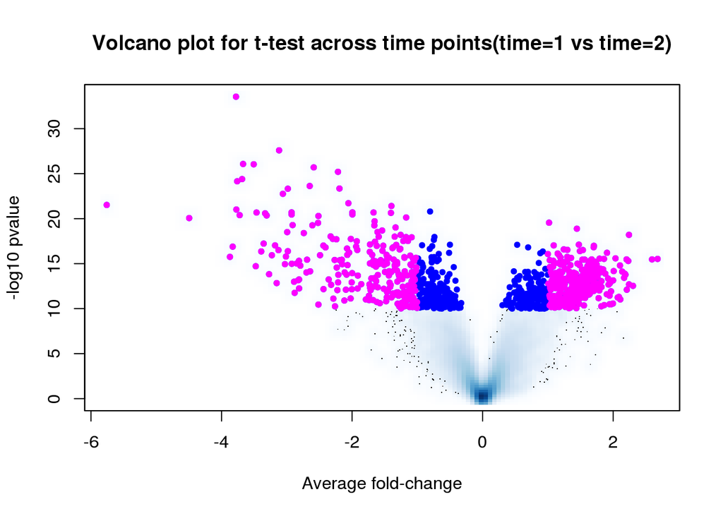

```r
Index1 <- which(stallcupdat$target$time==1)
Index2 <- which(stallcupdat$target$time==2)
Index3 <- which(stallcupdat$target$time==3)

d <- rowMeans(stallcupdat$E[,Index2])-rowMeans(stallcupdat$E[,Index1])

tt <- rowttests(stallcupdat$E[, c(Index1,Index2)], factor(stallcupdat$targets$time[c(Index1,Index2)]))
lodt <- -log10(tt$p.value)
smoothScatter(d,
              lodt,
              nrpoints=500,
              xlab="Average fold-change",
              ylab="-log10 pvalue",
              main="Volcano plot for t-test across time points(time=1 vs time=2)")
points(d[lodt>10], lodt[lodt>10], pch=20, col=4)
points(d[lodt>10 & abs(d)>1], lodt[lodt>10 & abs(d)>1], pch=20, col=6)
```

### Based on t-tests, there seem to be enough differentially expressed genes between time points 1 and time points 2 (Across treatments+control)

# Moderated t-tests

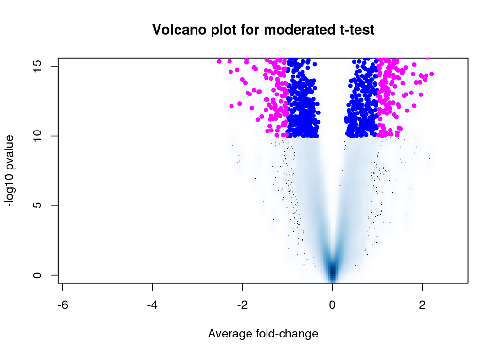

```r
design <- model.matrix(~factor(stallcupdat$target$time))
fit <- lmFit(stallcupdat$E, design)
efit <- eBayes(fit)
lodmt <- -log10(efit$p.value[,2])

d <- rowMeans(stallcupdat$E[,Index2])-rowMeans(stallcupdat$E[,Index1])

smoothScatter(d,
              lodmt,
              nrpoints=500,
              main="Volcano plot for moderated t-test",xlab="Average fold-change",
              ylab="-log10 pvalue",ylim=c(0,15))
points(d[lodmt>10], lodmt[lodmt>10], pch=20, col=4)
points(d[lodmt>10 & abs(d)>1],lodmt[lodmt>10 & abs(d)>1], pch=20, col=6)
```

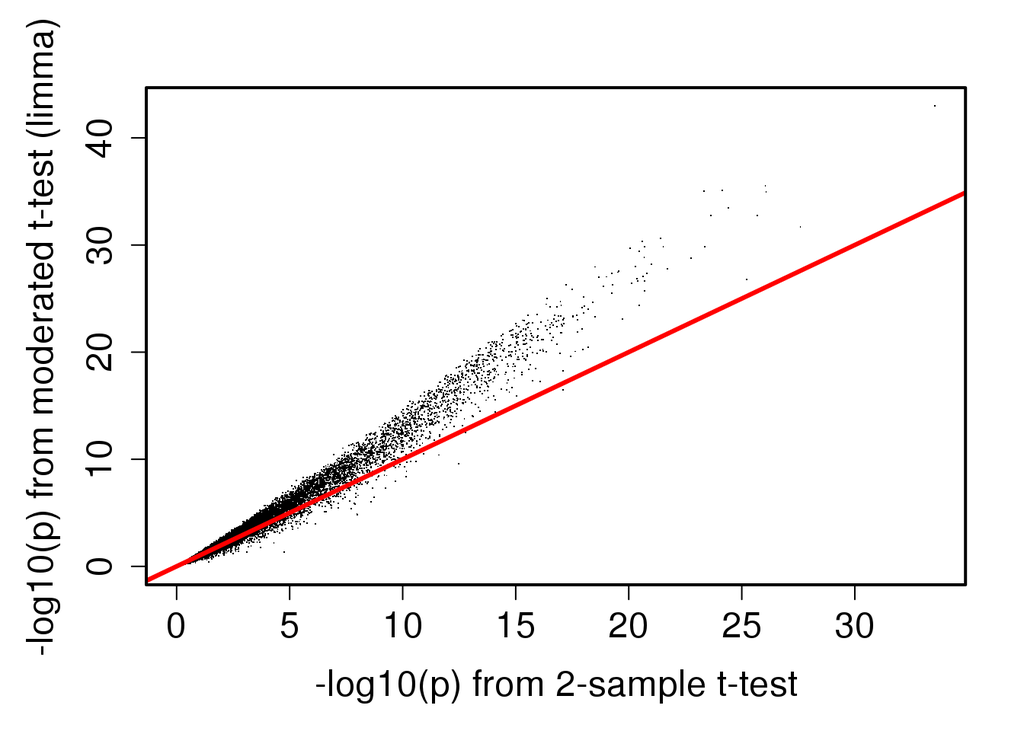

```r
par(mar=c(5,5,3,2))
plot(lodt,lodmt,pch=".",cex.axis=1.5,cex.lab=1.5,
     xlab="-log10(p) from 2-sample t-test",
     ylab="-log10(p) from moderated t-test (limma)")
abline(0,1,col=2,lwd=3)
box(lwd=2)
```

### As there are too few replicates(12 here) so the variance estimates can be stabilised using moderated t-tests. Clearly. in this case pooling variance information from similar genes helps as they p-value estimates improve.

# Finding DE genes

```r
time <- stallcupdat$targets$time
trts <- factor(stallcupdat$targets$treatment,
               levels=unique(stallcupdat$targets$treatment))
design <- model.matrix(~0+trts)
colnames(design) <- levels(trts)
kable(design)
```

| Control2 | X | Control1 | Y |
| --- | --- | --- | --- |
| 1 | 0 | 0 | 0 |
| 0 | 1 | 0 | 0 |
| 0 | 1 | 0 | 0 |
| 0 | 1 | 0 | 0 |
| 1 | 0 | 0 | 0 |
| 0 | 1 | 0 | 0 |
| 0 | 1 | 0 | 0 |
| 0 | 1 | 0 | 0 |
| 0 | 0 | 1 | 0 |
| 0 | 0 | 1 | 0 |
| 0 | 0 | 1 | 0 |
| 0 | 0 | 0 | 1 |
| 0 | 0 | 0 | 1 |
| 0 | 0 | 0 | 1 |
| 1 | 0 | 0 | 0 |
| 1 | 0 | 0 | 0 |
| 0 | 0 | 1 | 0 |
| 0 | 0 | 1 | 0 |
| 0 | 0 | 1 | 0 |
| 0 | 0 | 0 | 1 |
| 0 | 0 | 0 | 1 |
| 0 | 0 | 0 | 1 |
| 1 | 0 | 0 | 0 |
| 1 | 0 | 0 | 0 |
| 0 | 0 | 1 | 0 |
| 0 | 0 | 1 | 0 |
| 0 | 0 | 1 | 0 |
| 0 | 0 | 0 | 1 |
| 0 | 0 | 0 | 1 |
| 0 | 0 | 0 | 1 |
| 1 | 0 | 0 | 0 |
| 1 | 0 | 0 | 0 |
| 0 | 0 | 1 | 0 |
| 0 | 0 | 1 | 0 |
| 0 | 0 | 1 | 0 |
| 0 | 0 | 0 | 1 |
| 0 | 0 | 0 | 1 |
| 0 | 0 | 0 | 1 |
| 1 | 0 | 0 | 0 |
| 1 | 0 | 0 | 0 |
| 1 | 0 | 0 | 0 |
| 0 | 1 | 0 | 0 |
| 0 | 1 | 0 | 0 |
| 0 | 1 | 0 | 0 |
| 1 | 0 | 0 | 0 |
| 0 | 1 | 0 | 0 |
| 0 | 1 | 0 | 0 |
| 0 | 1 | 0 | 0 |

### We define a more explicit design matrix without intercept.

# Differential genes at time point 2

### We define an contrast matrix which is more easy to interpret than using vectors

```r
fit <- lmFit(stallcupdat$E[,c(time==2)],design[c(time==2),])

contr.matrix <- makeContrasts(XYsC1C2 = (X+Y)/2 - (Control1+Control2)/2,
                              XvsC1C2 = X-(Control1+Control2)/2,
                              YvsC1C2 = Y-(Control1+Control2)/2,
                              levels = design)
kable(contr.matrix )
```

|  | XYsC1C2 | XvsC1C2 | YvsC1C2 |
| --- | --- | --- | --- |
| Control2 | -0.5 | -0.5 | -0.5 |
| X | 0.5 | 1.0 | 0.0 |
| Control1 | -0.5 | -0.5 | -0.5 |
| Y | 0.5 | 0.0 | 1.0 |

```r
fitgpd=contrasts.fit(fit,contr.matrix)
fitgpd=eBayes(fitgpd)
topTable(fitgpd,n=10)
```

```
##                 XYsC1C2    XvsC1C2    YvsC1C2     AveExpr        F
## ILMN_2392261  1.4636316  1.9561086  0.9711547  0.05572692 90.92310
## ILMN_1760103  1.5530846  2.0300292  1.0761400  0.18434020 79.23543
## ILMN_1692223 -1.9220230 -1.8575570 -1.9864891 -0.25493441 54.06754
## ILMN_1688184  0.7892799  0.7565609  0.8219990  0.21793060 53.20783
## ILMN_1721559  1.5286137  1.9785469  1.0786805  0.06988887 51.27430
## ILMN_1678143  1.1178679  1.4761343  0.7596015  0.23695775 50.49902
## ILMN_1767685  1.5999404  1.6852403  1.5146405  0.30349530 49.89704
## ILMN_1765668  1.1264200  1.3279808  0.9248592 -0.12808822 48.10125
## ILMN_1744765 -2.1002668 -2.1216260 -2.0789077  0.22195917 46.93273
## ILMN_1659610 -1.2895246 -1.4403356 -1.1387137 -0.17105952 45.92719
##                   P.Value    adj.P.Val
## ILMN_2392261 6.323691e-09 0.0001550948
## ILMN_1760103 1.583799e-08 0.0001942212
## ILMN_1692223 1.912231e-07 0.0011159689
## ILMN_1688184 2.118156e-07 0.0011159689
## ILMN_1721559 2.680453e-07 0.0011159689
## ILMN_1678143 2.952292e-07 0.0011159689
## ILMN_1767685 3.185103e-07 0.0011159689
## ILMN_1765668 4.013873e-07 0.0012305530
## ILMN_1744765 4.684749e-07 0.0012766462
## ILMN_1659610 5.365566e-07 0.0013159586
```

### Here XvsC1C2 implies that differential expression was calculated by averaging over Control1 and Control2 values.

## A total of 193 genes are upregulated and 158 downregulated when comparing average X+Y over average C1+C2 at time point 2 alone (i.e. not accounting for common genes with X vs C1C2 or YvsC1C2)

```r
results <- decideTests(fitgpd,adjust.method="none")
a <- vennCounts(results)
print(a)
```

```
##   XYsC1C2 XvsC1C2 YvsC1C2 Counts
## 1       0       0       0  18148
## 2       0       0       1    283
## 3       0       1       0   1376
## 4       0       1       1      2
## 5       1       0       0    351
## 6       1       0       1    419
## 7       1       1       0   2530
## 8       1       1       1   1417
## attr(,"class")
## [1] "VennCounts"
```

```r
head(results,n=10)
```

```
##               Contrasts
##                XYsC1C2 XvsC1C2 YvsC1C2
##   ILMN_1762337       0       0       0
##   ILMN_2055271       0       0       0
##   ILMN_2383229       0       0       0
##   ILMN_1806310       0       0       0
##   ILMN_1779670       0       0       0
##   ILMN_2321282       0       0       0
##   ILMN_1772582       0       0       0
##   ILMN_1717783       0       0       0
##   ILMN_1814316       0       0       0
##   ILMN_2359168       0       0       0
```

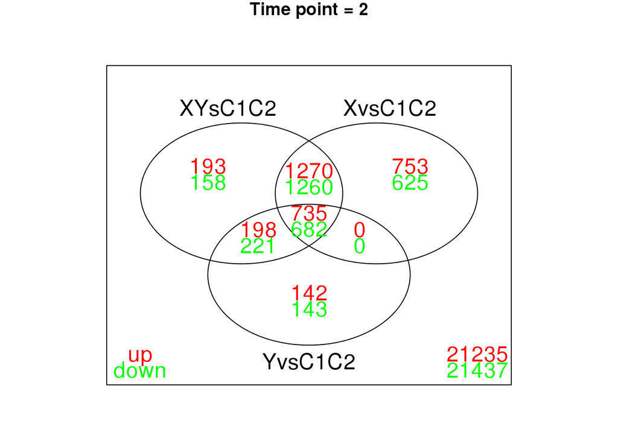

```r
vennDiagram(results,include=c("up","down"),counts.col=c("red","green"), main="Time point = 2")
```

### Let’s compare XvsY and XvsC1 and YvsC1

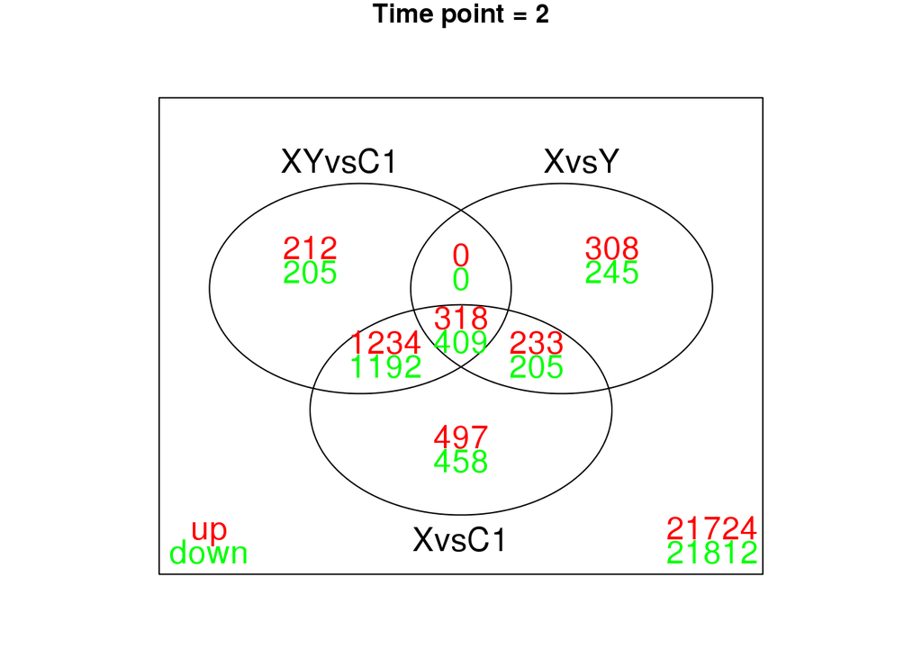

```r
contr.matrix <- makeContrasts(XYvsC1 = (X+Y)/2 - (Control1), XvsY = X-Y, XvsC1= X-Control1, levels = design)
fitgpd <- contrasts.fit(fit,contr.matrix)
fitgpd <- eBayes(fitgpd)
results <- decideTests(fitgpd, adjust.method="none")
cs <- vennCounts(results)
vennDiagram(results, include=c("up","down"),counts.col=c("red","green"), main="Time point = 2")
```

```r
head(results,n=10)
```

```
##               Contrasts
##                XYvsC1 XvsY XvsC1
##   ILMN_1762337      0    0     0
##   ILMN_2055271      0    0     0
##   ILMN_2383229      0    0     0
##   ILMN_1806310      0    0     0
##   ILMN_1779670      0    0     0
##   ILMN_2321282      0    0     0
##   ILMN_1772582      0    0     0
##   ILMN_1717783      0    0     0
##   ILMN_1814316      0    0     0
##   ILMN_2359168      0    0     0
```

```r
print(vennCounts(results,include=c("up")))
```

```
##   XYvsC1 XvsY XvsC1 Counts
## 1      0    0     0  21724
## 2      0    0     1    497
## 3      0    1     0    308
## 4      0    1     1    233
## 5      1    0     0    212
## 6      1    0     1   1234
## 7      1    1     0      0
## 8      1    1     1    318
## attr(,"class")
## [1] "VennCounts"
```

```r
print(vennCounts(results,include=c("down")))
```

```
##   XYvsC1 XvsY XvsC1 Counts
## 1      0    0     0  21812
## 2      0    0     1    458
## 3      0    1     0    245
## 4      0    1     1    205
## 5      1    0     0    205
## 6      1    0     1   1192
## 7      1    1     0      0
## 8      1    1     1    409
## attr(,"class")
## [1] "VennCounts"
```

### A striking number that stands out is 0 up and downregulated genes between XYvsC1 and XvsY, thus indicating that there are no such genes which are diff expressed in (X+Y)vsC1C2 or XvsY or XvsC1 however there are genes which are in common up or down regulated in all these groups.

## Differential genes at time point 3

```r
fit <- lmFit(stallcupdat$E[,c(time==3)],design[c(time==3),])

contr.matrix <- makeContrasts(XYsC1C2 = (X+Y)/2 - (Control1+Control2)/2,
                              XvsC1C2 = X-(Control1+Control2)/2,
                              YvsC1C2 = Y-(Control1+Control2)/2,
                              levels = design)
kable(contr.matrix )
```

|  | XYsC1C2 | XvsC1C2 | YvsC1C2 |
| --- | --- | --- | --- |
| Control2 | -0.5 | -0.5 | -0.5 |
| X | 0.5 | 1.0 | 0.0 |
| Control1 | -0.5 | -0.5 | -0.5 |
| Y | 0.5 | 0.0 | 1.0 |

```r
fitgpd=contrasts.fit(fit,contr.matrix)
fitgpd=eBayes(fitgpd)
kable(topTable(fitgpd,n=10))
```

|  | XYsC1C2 | XvsC1C2 | YvsC1C2 | AveExpr | F | P.Value | adj.P.Val |
| --- | --- | --- | --- | --- | --- | --- | --- |
| ILMN_1692223 | -1.8940198 | -1.9449983 | -1.8430414 | -0.4530204 | 82.71110 | 0e+00 | 0.0001927 |
| ILMN_1721559 | 1.4268679 | 1.6331010 | 1.2206347 | 0.1593326 | 71.53020 | 0e+00 | 0.0002601 |
| ILMN_1701424 | 1.0294645 | 1.2389639 | 0.8199651 | 0.2988811 | 65.88971 | 0e+00 | 0.0003023 |
| ILMN_2382290 | 0.8318677 | 0.8472919 | 0.8164435 | 0.2804587 | 52.94152 | 2e-07 | 0.0009729 |
| ILMN_2096985 | -0.8602917 | -1.0186670 | -0.7019164 | -0.1337231 | 50.87320 | 2e-07 | 0.0010107 |
| ILMN_1755811 | -0.7159714 | -0.8606184 | -0.5713244 | -0.0355728 | 48.77121 | 3e-07 | 0.0011091 |
| ILMN_1792679 | 0.6616360 | 0.7118095 | 0.6114625 | 0.2222735 | 45.79061 | 4e-07 | 0.0014301 |
| ILMN_2072622 | 0.7368801 | 1.0632469 | 0.4105133 | 0.3582748 | 43.31539 | 6e-07 | 0.0015061 |
| ILMN_1702301 | 0.4475621 | 0.4663214 | 0.4288029 | -0.0008716 | 41.71393 | 7e-07 | 0.0015061 |
| ILMN_1775829 | -0.7633448 | -0.9708421 | -0.5558475 | -0.0260578 | 41.60169 | 8e-07 | 0.0015061 |

### Lots of common genes between XYvsC1C2 and XvsC1C2

```r
results <- decideTests(fitgpd,adjust.method="none")
a <- vennCounts(results)
head(results,n=10)
```

```
##               Contrasts
##                XYsC1C2 XvsC1C2 YvsC1C2
##   ILMN_1762337       0       0       0
##   ILMN_2055271       0       0       0
##   ILMN_2383229       0       0       0
##   ILMN_1806310       0       0       0
##   ILMN_1779670       0       0       0
##   ILMN_2321282       0       0       0
##   ILMN_1772582      -1      -1       0
##   ILMN_1717783       0       1       0
##   ILMN_1814316       0       0       0
##   ILMN_2359168       0       0       0
```

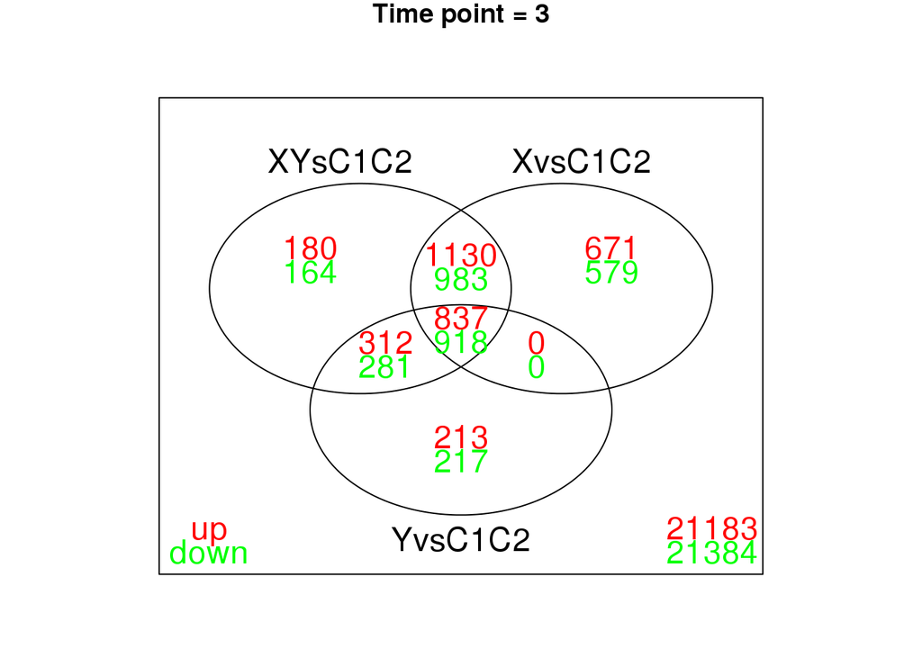

```r
vennDiagram(results,include=c("up","down"),counts.col=c("red","green"), main="Time point = 3")
```

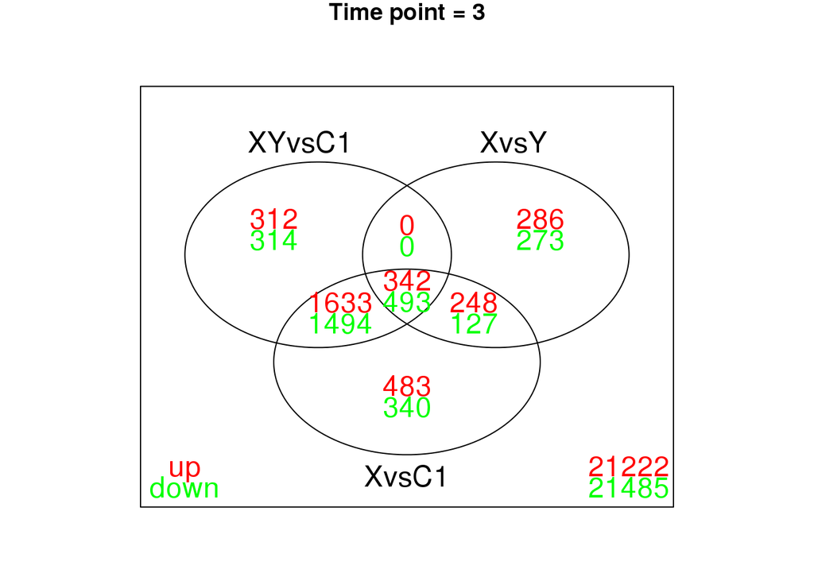

```r
contr.matrix <- makeContrasts(XYvsC1 = (X+Y)/2 - (Control1), XvsY = X-Y, XvsC1= X-Control1, levels = design)
fitgpd <- contrasts.fit(fit,contr.matrix)
fitgpd <- eBayes(fitgpd)
results <- decideTests(fitgpd, adjust.method="none")
cs <- vennCounts(results)
vennDiagram(results, include=c("up","down"),counts.col=c("red","green"), main="Time point = 3")
```

```r
head(results,n=10)
```

```
##               Contrasts
##                XYvsC1 XvsY XvsC1
##   ILMN_1762337      0    0     0
##   ILMN_2055271      0    0     0
##   ILMN_2383229      0    0     0
##   ILMN_1806310      0    0     0
##   ILMN_1779670      0    0     0
##   ILMN_2321282      0    0     0
##   ILMN_1772582     -1    0    -1
##   ILMN_1717783      0    0     0
##   ILMN_1814316      0    0     0
##   ILMN_2359168      0    0     0
```

```r
print(vennCounts(results,include=c("up")))
```

```
##   XYvsC1 XvsY XvsC1 Counts
## 1      0    0     0  21222
## 2      0    0     1    483
## 3      0    1     0    286
## 4      0    1     1    248
## 5      1    0     0    312
## 6      1    0     1   1633
## 7      1    1     0      0
## 8      1    1     1    342
## attr(,"class")
## [1] "VennCounts"
```

```r
print(vennCounts(results,include=c("down")))
```

```
##   XYvsC1 XvsY XvsC1 Counts
## 1      0    0     0  21485
## 2      0    0     1    340
## 3      0    1     0    273
## 4      0    1     1    127
## 5      1    0     0    314
## 6      1    0     1   1494
## 7      1    1     0      0
## 8      1    1     1    493
## attr(,"class")
## [1] "VennCounts"
```

### Again no common genes between XYvsC1 and XvsY which are not in XvsC1.

## DE genes associated with time

Reference: https://www.bioconductor.org/packages/devel/bioc/vignettes/limma/inst/doc/usersguide.pdf Section 9.6

```r
time <- factor(stallcupdat$targets$time)
trts <- factor(stallcupdat$targets$treatment,
             levels=unique(stallcupdat$targets$treatment))

design <- model.matrix(~0+trts*time)
colnames(design) <- c('Control2', 'X', 'Control1', 'Y', 'time2', 'time3', 'X.time2', 'Control1.time2', 'Y.time2', 'X.time3', 'Control1.time3', 'Y.time3')
fit <- lmFit(stallcupdat$E,design)
contr.matrix <- makeContrasts(XYvsC1C2  = (X+Y)/2-(Control1+Control2)/2,
                              X3Y3vsX2Y2 = (X.time3+Y.time3)/2-(X.time2+Y.time2)/2,
                              X3vsX2 = X.time3-X.time2,
                              levels = design)
kable(contr.matrix)
```

|  | XYvsC1C2 | X3Y3vsX2Y2 | X3vsX2 |
| --- | --- | --- | --- |
| Control2 | -0.5 | 0.0 | 0 |
| X | 0.5 | 0.0 | 0 |
| Control1 | -0.5 | 0.0 | 0 |
| Y | 0.5 | 0.0 | 0 |
| time2 | 0.0 | 0.0 | 0 |
| time3 | 0.0 | 0.0 | 0 |
| X.time2 | 0.0 | -0.5 | -1 |
| Control1.time2 | 0.0 | 0.0 | 0 |
| Y.time2 | 0.0 | -0.5 | 0 |
| X.time3 | 0.0 | 0.5 | 1 |
| Control1.time3 | 0.0 | 0.0 | 0 |
| Y.time3 | 0.0 | 0.5 | 0 |

```r
fitgpd=contrasts.fit(fit,contr.matrix)
fitgpd=eBayes(fitgpd)
kable(topTable(fitgpd,n=10))
```

|  | XYvsC1C2 | X3Y3vsX2Y2 | X3vsX2 | AveExpr | F | P.Value | adj.P.Val |
| --- | --- | --- | --- | --- | --- | --- | --- |
| ILMN_2167758 | -1.3896028 | -0.0688103 | -0.1023459 | 0 | 44.19823 | 0 | 0.00e+00 |
| ILMN_1692223 | -2.1329445 | 0.0127492 | -0.1026954 | 0 | 41.95023 | 0 | 0.00e+00 |
| ILMN_1655595 | 1.0482834 | 0.0033124 | 0.0069149 | 0 | 40.00381 | 0 | 0.00e+00 |
| ILMN_1767685 | 1.7273583 | -0.1139329 | 0.0082781 | 0 | 35.23824 | 0 | 2.00e-07 |
| ILMN_1716658 | -0.9511261 | 0.0106308 | -0.0062736 | 0 | 34.50571 | 0 | 2.00e-07 |
| ILMN_1755796 | -1.3112695 | -0.6494273 | -0.5966956 | 0 | 32.94084 | 0 | 4.00e-07 |
| ILMN_1765668 | 1.3044230 | -0.2756104 | -0.3990895 | 0 | 32.56274 | 0 | 4.00e-07 |
| ILMN_1768577 | -1.0893185 | -0.2411923 | -0.2485188 | 0 | 28.40039 | 0 | 2.10e-06 |
| ILMN_1652407 | 0.6911198 | -0.1529714 | -0.1781824 | 0 | 25.46233 | 0 | 7.60e-06 |
| ILMN_2388547 | 0.7136707 | 0.3246403 | 0.6653724 | 0 | 24.63418 | 0 | 1.04e-05 |

```r
results <- decideTests(fitgpd,adjust.method="none") # doesn't subset of F<0.05'
a <- vennCounts(results)
print(a)
```

```
##   XYvsC1C2 X3Y3vsX2Y2 X3vsX2 Counts
## 1        0          0      0  20073
## 2        0          0      1    366
## 3        0          1      0    447
## 4        0          1      1    520
## 5        1          0      0   2897
## 6        1          0      1     51
## 7        1          1      0     67
## 8        1          1      1    105
## attr(,"class")
## [1] "VennCounts"
```

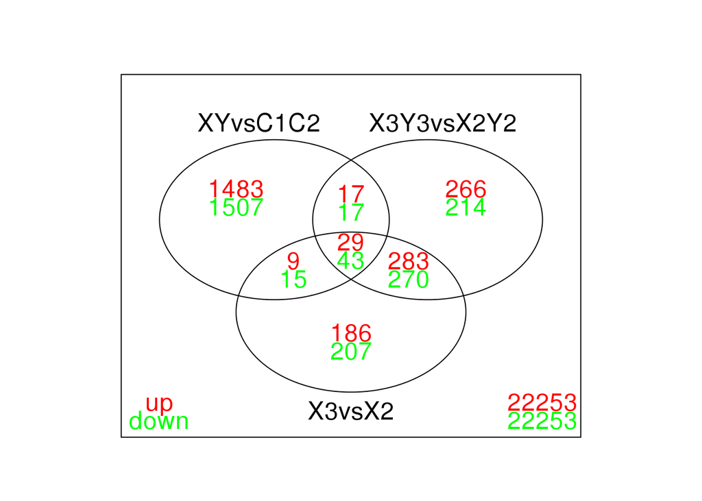

```r
vennDiagram(results, include=c("up","down"),counts.col=c("red","green"))
```

### The number of up or down regulated genes are more affected by the treatment type than by time as these numbers are less

### when comparing based on time points.